# A glimpse into the voters demographics: Democrats vs Republicans

WendyD

9/21/2020

# A little bit about our data

The goal of this project is to look deeper in to voter background and voting behavior using open-sourced data from the American National Election Studies (ANES). We work with the cumulative time series data, compiled between 1948 - 2016. The raw data consists of 59944 observations with 1029 variables. Only relevant subset was extracted and cleaned from the raw data set. The processed data could be found in the `output` folder.

# Introduction

This project glimpses into the education level difference between Democrat voters and Republican voters.

Specifically, this report aims to elucidate which education level makes up the majority of each voting group, their preferences, and what they like and dislike about the parties of their choice. To potentially explain their voting choices, we also look at their feeling toward various issues, for instance, immigration.

The project also look closer into the voting trend in 2016. Through this exploratory analysis, we hypothesize that aggressive immigration agenda is a big factor of Trump’s success 2016.

There are 3 main questions that we aim to explore in this project:

- What are the voters’ education level distribution for each party?
- What does a particular voter likes/dislikes about his/her preferred party?
- How do each education group feel about Trump’s immigration agenda?

# Question 1: Republican vs Democratics: which party has a “smarter” voting base?

Graduated from a liberal art college in Minnesota, a historically blue state, we always assumed that people with higher education levels tend to support the Democrat party. After all, Republican party is usually associated with climate change skepticism, evolution deniers, and anti-LGBT policies.

To answer this question, we look at the education distribution of the voters versus political identification. To illustrate our analysis, we first start with 2016 as an example.

Since the respondent political distribution does not necessary reflects the true population, percentage distribution is a better indicator compared to counting number of respondents.

```
##             Grade School High School Some Colleges no degree College or higher
## Democratics    1.3513514     23.7526                32.74428          42.15177
## Republican     0.6980803     22.2804                37.28912          39.73240
```

In 2016, people who have college degrees and higher tend to identify themselves as Democrats, though this difference does not seem significant. Let us look at the data across the year, to see if this phenomenon still applies over time

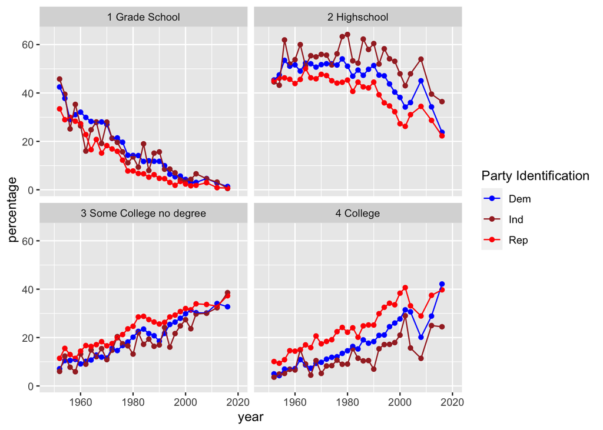

This could be due to two apparent reasons. There have been more and more people getting higher degrees, thus introducing an upward trends in some college and colleges education groups on the graph. This is due to more and more jobs require at least a college degree, which can be corroborated by looking at studies on job distribution over time.

Alternately, it could be a bias of the ANES survey. If the survey transitions from in-person interviews to remote interview through Internet, this could hinder less educated population taking the survey. This bias is harder to account for.

This realization came to us as a total surprise. The stereotype we have from college, that Republican voters are less educated than Democrat voters, is incorrect. For a more quantitative measure, we look at this percentage difference between the Democrats and Republicans for each of the educational groups

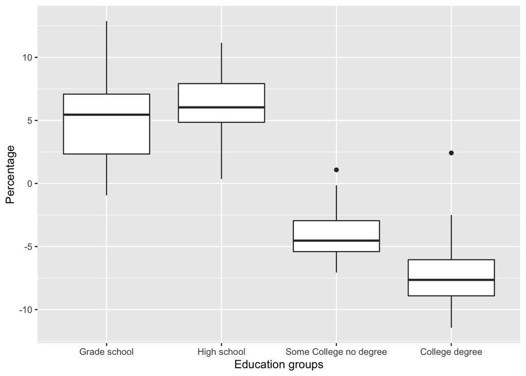

This boxplot reinforces the two observations we had above

- People with high school degree or lower tend to vote for Democrats more. On the other hands, Republicans have a stronger base in higher educational groups (college degree or higher).
- 2016 is an outlier for the `college and higher` category, while 2012 is an outlier for the `some colleges` category. This indicates two possible shifts in political preference: either higher educated group switching to Democrat, or less educated group switching to Republican. To find out which one is the case, we need further correction to the population bias mentioned above (i.e. respondent political distribution mirrors true population). Moving forward, we present some argument of why the second case fit better with the big picture.

# Question 2: What make a person choose one party over the other?

Next, we looked further at voter responses across different education background to the following questions: *what do you like/dislike about the party?* The responses were converted into word-clouds based on keyword frequency. These plots reveal some interesting insights.

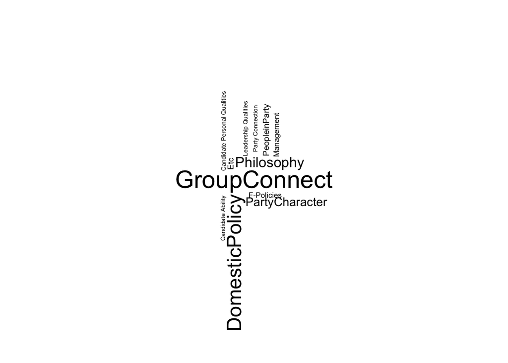

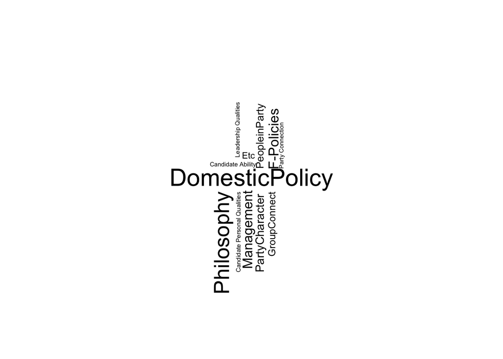

The Democrat party wins favor through their `Group Connection` and `Domestic Policies`. Republican voters, on the other hand, resonate with the Republican Party on their `Domestic Policy`, `Philosophy`, and `Management skills`.

The same process is repeated with the following question: *What do you hate about each parties?*

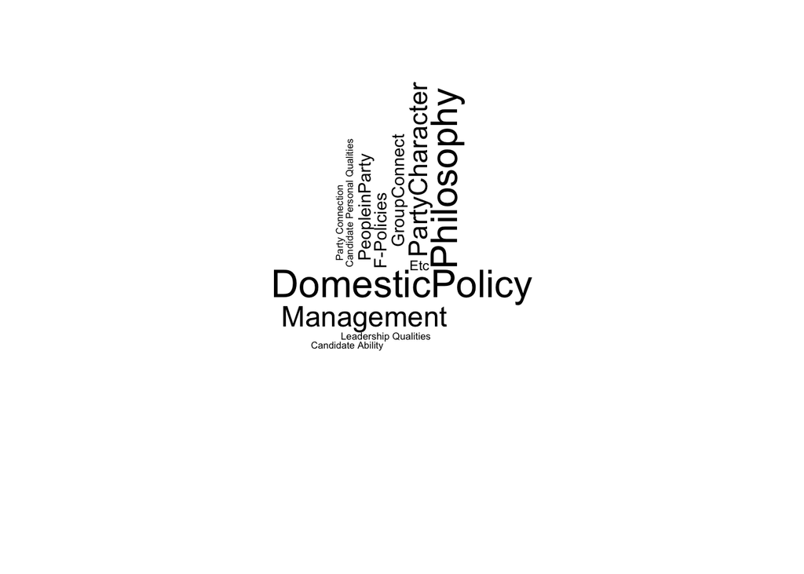

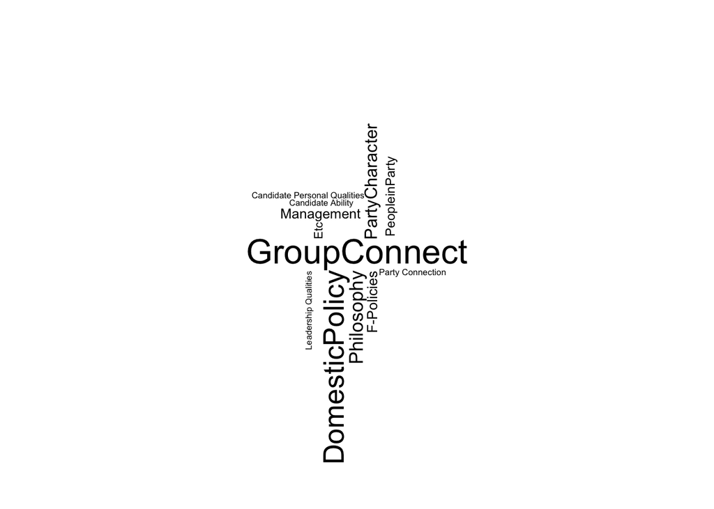

# Question 3: Why Donald Trump win? Does his agenda make sense?

Next, we looked at the voter `thermometer` toward the Democratic Party across the years versus specifically 2016 data.

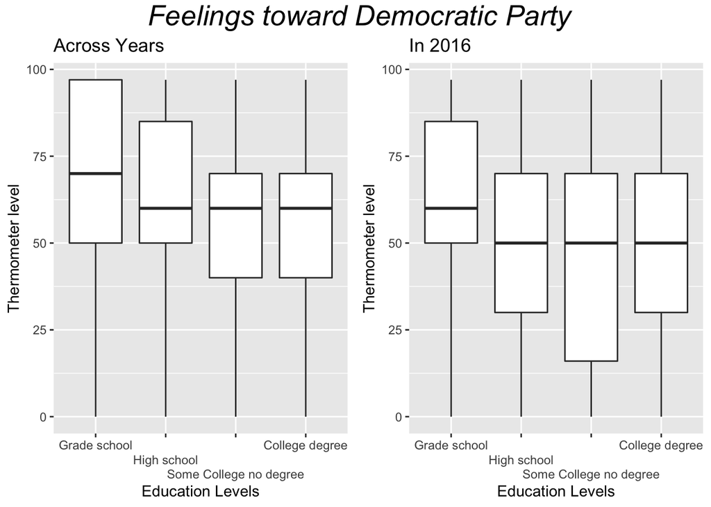

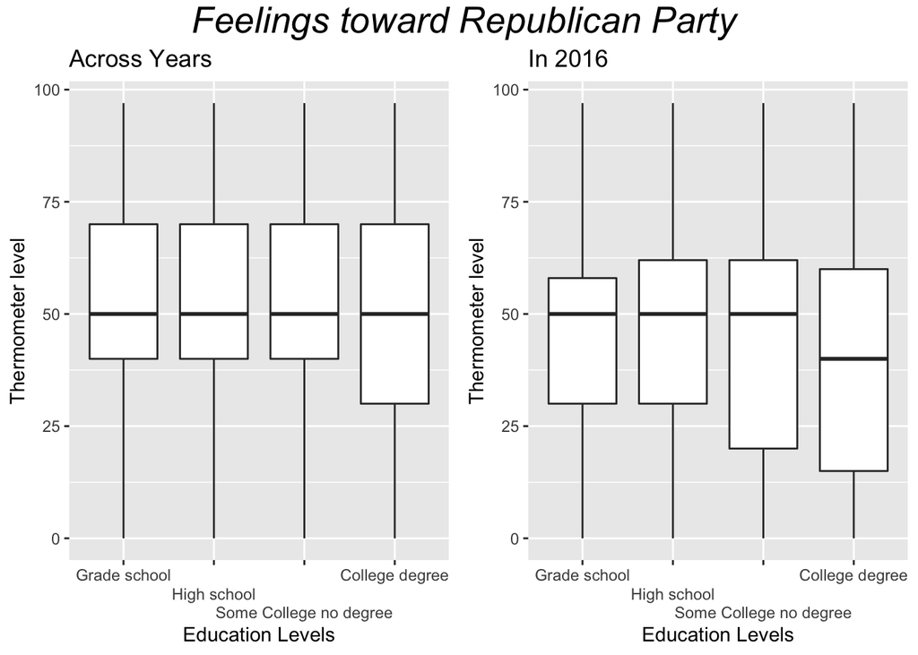

There is a uniform decrease in feeling toward the Democratic Party across different educations groups. This change is most likely a time-biased, similar to the effect we saw in figure 1. However, interestingly people feeling toward Republican party remains relatively unchanged, especially for the less educated group. This suggests that in 2016, Donald Trump succeeded in attracting voters from this population from the Democrats.

What could be the reason? In this analysis, we offer a potential reason for this shift in voting base by analyzing one of Trump’s most prominent agenda: immigration.

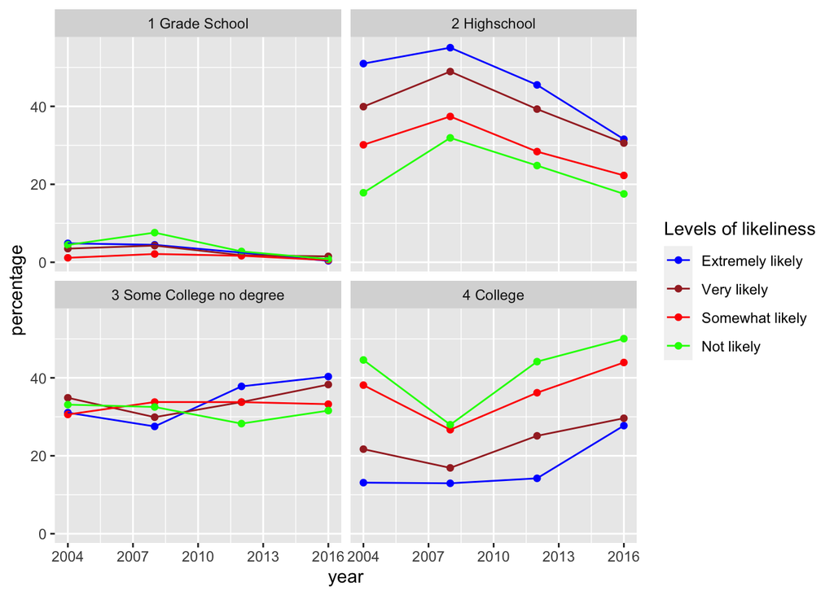

Most people who only have high school degrees deem the chance that immigrants will steal their jobs is *extremely likely*. As shown above, this group is a strong Democrat base. In `Some College degrees` educational group, where the Republicans lead the Democrats, there is an uptrend in voters feeling negatively about immigrants because of job prospect.

This observation indicates potential connection to Trump’s aggressive immigration agenda in 2016. His top agenda include building the wall, banning all Muslims, deporting undocumented immigrants who have lived in the United States for years, and increasing restrictions on highly skilled worker VISA H1-B. It is hard to verify that his agenda was actually crafted to extract this large base of voters from the Democrats, but it had a tremendous impact.

## Trump’s agenda sounds idiotic, ruthless yet extremely effective

Trump purposely used his immigration agenda to target and attract democratic voting base: people who have high school and grade school degrees and who strongly believe immigrants are stealing there jobs.

# Biases

This section summarizes some of the biases mentioned in the report, as well as some that should be taken into consideration in future works.

A respondent bias comes from the fact that people were paid to do the survey. Similarly, the mean of taking survey may exclude certain groups from participating.

Furthermore, there are differences in sample sizes across the years that the surveys took place. There was less data recorded in the 1990s compared to the 2010-2016 period. These uncertainties can be incorporated into the visualizations above through error bars, for instance.

Interviewer bias may also take place. For example,at one-on-one interviews, respondents can be influenced by the administrators’ body languages, expressions, or simply demographic or race.

The biases influencing the voter distribution between the two parties were taken into account. As explained above, we worked with the percentage distribution and percentage difference between each education group, rather than considering the raw numbers. Nonetheless, other surveys will prove to be valuable to examining the points raised in this report.

# Conclusion

Voters are attracted to the Democratic Party on their `group connection quality` and `domestic policies`, while the Republicans gain favor through their `management skills` and also `domestic policies`. Voters hate the Democrats for their poor `management skills`, and Republicans for their lack of `group connections`.

People who only have `high school degree` tend to think immigrants will likely steal their jobs. People having `college degrees` or higher tend to think less so. Although, we observed some upward trend in the number of people with `some college` degree thinking negatively about immigration impact on the job market, though the significance is open to further analysis.